# hw8

Author

Jessica Villanueva

Function practice:

```r
# practice writing functions
randWalk <- function(n = 50) { # parameter: how many steps to take
  pos <- 0
  vec <- c(0)
  for(i in 1:n){
    pos <- pos + sample(c(-1, 1), size = 1)
    vec <- append(vec, pos)
  }
  vec
}

randWalk(100)
```

```
  [1]  0 -1  0 -1 -2 -3 -2 -3 -4 -5 -4 -3 -4 -5 -6 -7 -6 -7 -8 -9 -8 -7 -6 -5 -4
 [26] -3 -4 -5 -4 -3 -4 -3 -2 -3 -2 -1  0  1  0  1  0 -1  0 -1  0 -1 -2 -1 -2 -1
 [51] -2 -3 -2 -3 -2 -1  0 -1 -2 -1  0  1  0  1  0  1  0 -1 -2 -3 -2 -3 -2 -1 -2
 [76] -1 -2 -3 -4 -5 -4 -5 -4 -5 -4 -3 -4 -3 -4 -3 -4 -3 -4 -5 -6 -5 -6 -7 -8 -7
[101] -8
```

```r
walk2 <- function(n = 50){
  steps <- sample(c(-1, 1), size = n, replace = TRUE)
  cumsum(steps)
}

walk2(100)
```

```
  [1]  -1  -2  -1   0  -1  -2  -1  -2  -3  -4  -3  -4  -3  -4  -5  -6  -7  -8
 [19]  -9 -10  -9  -8  -9  -8  -9  -8  -9  -8  -9  -8  -7  -6  -7  -8  -7  -8
 [37]  -9 -10  -9  -8  -9  -8  -7  -6  -7  -8  -9 -10  -9  -8  -7  -6  -5  -6
 [55]  -7  -6  -7  -8  -7  -6  -7  -8  -9 -10  -9  -8  -9 -10 -11 -10 -11 -12
 [73] -11 -12 -13 -14 -13 -12 -13 -12 -13 -14 -15 -16 -17 -16 -15 -16 -17 -18
 [91] -17 -16 -15 -16 -15 -14 -15 -16 -17 -16
```

```r
# print square numbers of the first 5 integers
for(i in 1:5){ # can also use seq(5)
  print(i^2)
}
```

```
[1] 1
[1] 4
[1] 9
[1] 16
[1] 25
```

```r
library(tidyverse)
```

## Initializing the Infection

Write a function that initializes the disease simulation by randomly infecting some proportion of the population. The function should accept these arguments:

- number of rows in the grid
- number of columns in the grid
- probability each cell starts out infected, defaulting to 0.1.

Hint: Use a matrix with 0’s representing susceptible, 1 for infected and 2 for removed.

```r
set.seed(34890)
randInfect <- function(row, col, prob = 0.1){
  X <- matrix(0, row, col) # 0 indicating susceptible
  infected <- sample(c(TRUE, FALSE), row * col, replace = TRUE, prob = c(prob, 1 - prob))
  infected <- matrix(infected, nrow = row)
  X[infected] <- 1 # 1 indicating infected
  X
}

# testing function
randInfect(4, 5)
```

```
     [,1] [,2] [,3] [,4] [,5]
[1,]    0    0    0    1    0
[2,]    1    0    0    0    0
[3,]    0    0    0    0    0
[4,]    0    0    0    0    0
```

## Plotting the Infection

Write a function to plot the Susceptible, Infected, and Removed cells with the colors white, red, and grey, respectively.

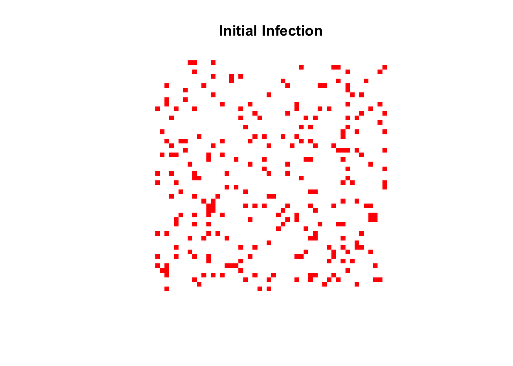

```r
plotInitMatrix <- function(X){
  newX <- apply(X, 2, rev)
  image(t(newX), col = c("white", "red"), axes = FALSE, asp = 1)
  title(main = "Initial Infection")
}

plotMatrix <- function(X, title = "Infection"){
  newX <- apply(X, 2, rev)
  image(t(newX), col = c("white", "red", "gray"), axes = FALSE, asp = 1)
  title(main = title)
}

# testing the function
plotInitMatrix(randInfect(50, 50))
```

## Spreading the Infection

Use vectorized code (not a for loop) to randomly infect approximately 50% of the cells EITHER ABOVE OR BELOW the infected cells. This is part of one step in the process. A full step will expose 8 neighboring cells to infection: 4 sides, and 4 corners.

Plot your results to demonstrate correctness.

1. Use par(mfrow = c(1, 2)) for two side by side plots.
2. Index into the matrix by selecting all elements excluding the first or last row.

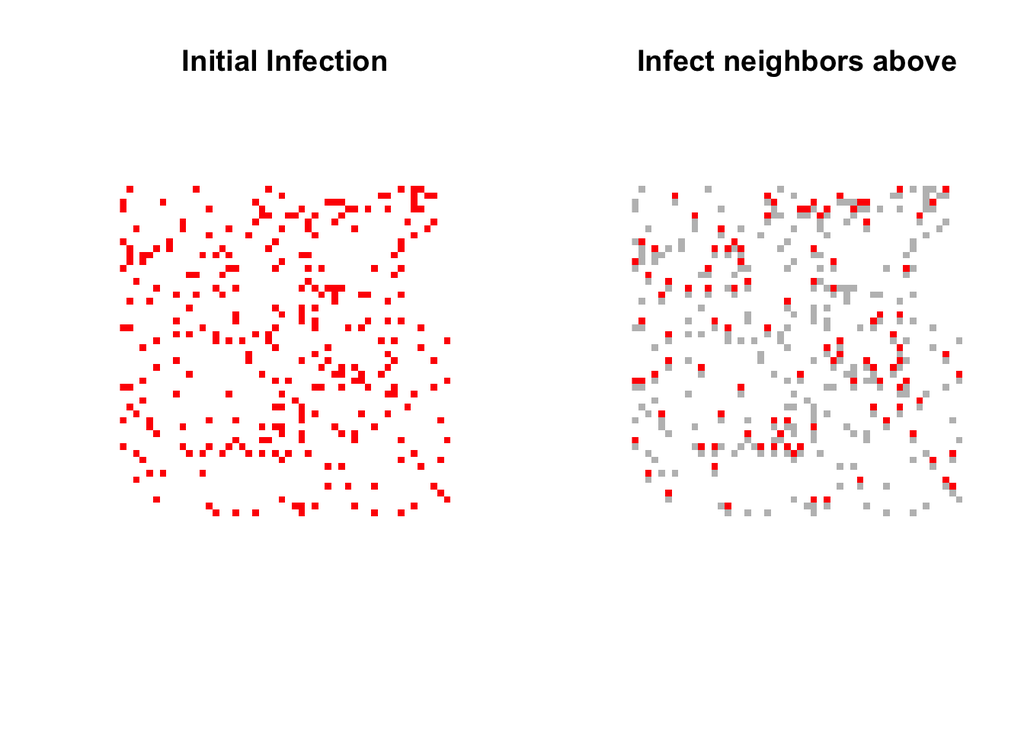

```r
par(mfrow = c(1, 2))

# infecting upwards (above)
# boolean matrix of those who have had close contact with the cell above
cc_above <- sample(c(FALSE, TRUE), prob = c(0.5, 1 - 0.5),
                   size = (50 - 1) * 50, replace = TRUE)
cc_above <- matrix(cc_above, nrow = 50 - 1, ncol = 50)
# the inital matrix of cells infected
Y <- randInfect(50, 50)
# boolean matrix of a cell that had close contact with an **infected** cell
new_infection_above <- Y[-1, ] == 1 & cc_above
# applying the new infected cells to the original matrix, including removed cells
Yabove <- Y
Yabove[-50 , ][new_infection_above] <- 1
Yabove[Y == 1] <- 2

plotInitMatrix(Y)
plotMatrix(Yabove, "Infect neighbors above")
```

## Full Simulation

Extend the step above to all 8 neighbors of a cell by writing a function that performs a single infection step. The rule is that each infected cell infects susceptible neighbors with some fixed probability. Vectorized code or explicit for loops are both fine. The function should accept the following:

1. Data structure representing the current SIR (susceptible, infected, removed) state. This will be a matrix if you’re following the standard advice. 🤔
2. Probability of infection, defaulting to 0.125

Plot your results for a single step to demonstrate correctness. Your plot should resemble the one below, with new infections occurring randomly on all sides and corners of old infections.

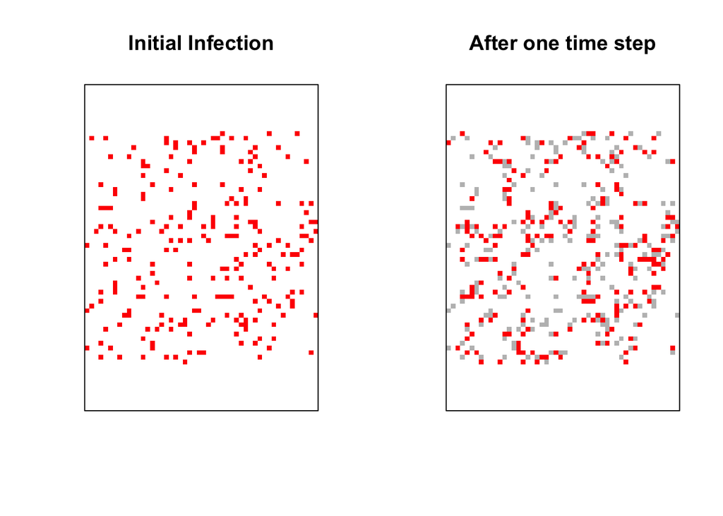

```r
# displays two images side by side
par(mfrow = c(1, 2))

infection <- function(X, prob = 0.125){
  # infecting upwards (above)   -------------------------------------------------------
  # boolean matrix of those who have had close contact with the cell above
  cc_above <- sample(c(TRUE, FALSE), prob = c(prob, 1 - prob),
                     size = (nrow(X) - 1) * ncol(X), replace = TRUE)
  cc_above <- matrix(cc_above, nrow = nrow(X) - 1, ncol = ncol(X))
  # boolean matrix of a cell that had close contact with an **infected** cell
  new_infection_above <- X[-1, ] == 1 & cc_above
  # applying the new infected cells to the original matrix
  Xabove <- X
  Xabove[-nrow(X) , ][new_infection_above] <- 1


  # infecting downwards (below) -------------------------------------------------------
  cc_below <- sample(c(TRUE, FALSE), prob = c(prob, 1 - prob),
                     size = (nrow(X) - 1) * ncol(X), replace = TRUE)
  cc_below <- matrix(cc_below, nrow = nrow(X) - 1, ncol = ncol(X))
  new_infection_below <- X[-nrow(X), ] == 1 & cc_below
  Xbelow <- X
  Xbelow[-1 , ][new_infection_below] <- 1

  # infecting to the right      -------------------------------------------------------
  cc_right <- sample(c(TRUE, FALSE), prob = c(prob, 1 - prob),
                     size = nrow(X) * (ncol(X) - 1), replace = TRUE)
  cc_right <- matrix(cc_right, nrow = nrow(X), ncol = ncol(X) - 1)
  new_infection_right <- X[ , -ncol(X)] == 1 & cc_right
  Xright <- X
  Xright[ , -1][new_infection_right] <- 1

  # infecting to the left       -------------------------------------------------------
  cc_left <- sample(c(TRUE, FALSE), prob = c(prob, 1 - prob),
                     size = nrow(X) * (ncol(X) - 1), replace = TRUE)
  cc_left <- matrix(cc_left, nrow = nrow(X), ncol = ncol(X) - 1)
  new_infection_left <- X[ , -1] == 1 & cc_left
  Xleft <- X
  Xleft[ , -ncol(X)][new_infection_left] <- 1

  # infecting northeast         -------------------------------------------------------
  cc_northeast <- sample(c(TRUE, FALSE), prob = c(prob, 1 - prob),
                   size = (nrow(X) - 1) * (ncol(X) - 1), replace = TRUE)
  cc_northeast <- matrix(cc_northeast, nrow = nrow(X) - 1, ncol = ncol(X) - 1)
  new_infection_northeast <- X[-1, -ncol(X)] == 1 & cc_northeast
  Xnortheast <- X
  Xnortheast[-nrow(X) , -1][new_infection_northeast] <- 1

  # infecting southeast         -------------------------------------------------------
  cc_southeast <- sample(c(TRUE, FALSE), prob = c(prob, 1 - prob),
                   size = (nrow(X) - 1) * (ncol(X) - 1), replace = TRUE)
  cc_southeast <- matrix(cc_southeast, nrow = nrow(X) - 1, ncol = ncol(X) - 1)
  new_infection_southeast <- X[-nrow(X), -ncol(X)] == 1 & cc_southeast
  Xsoutheast <- X
  Xsoutheast[-1 , -1][new_infection_southeast] <- 1

  # infecting northwest         -------------------------------------------------------
  cc_northwest <- sample(c(TRUE, FALSE), prob = c(prob, 1 - prob),
                   size = (nrow(X) - 1) * (ncol(X) - 1), replace = TRUE)
  cc_northwest <- matrix(cc_northwest, nrow = nrow(X) - 1, ncol = ncol(X) - 1)
  new_infection_northwest <- X[-1, -1] == 1 & cc_northwest
  Xnorthwest <- X
  Xnorthwest[-nrow(X) , -ncol(X)][new_infection_northwest] <- 1

  # infecting southwest         -------------------------------------------------------
  cc_southwest <- sample(c(TRUE, FALSE), prob = c(prob, 1 - prob),
                   size = (nrow(X) - 1) * (ncol(X) - 1), replace = TRUE)
  cc_southwest <- matrix(cc_southwest, nrow = nrow(X) - 1, ncol = ncol(X) - 1)
  new_infection_southwest <- X[-nrow(X), -1] == 1 & cc_southwest
  Xsouthwest <- X
  Xsouthwest[-1 , -ncol(X)][new_infection_southwest] <- 1


  # combine all matrices (do at end)
  newX <- Xbelow | Xabove | Xright | Xleft | Xnortheast | Xsoutheast | Xnorthwest | Xsouthwest
  newX[X == 1] <- 2
  newX
}

# inital infection
initInfect <- randInfect(50, 50)
# spreading the infection
nextInfect <- infection(initInfect)

# plotting
plotInitMatrix(initInfect)
box()
plotMatrix(nextInfect, "After one time step")
box()
```